# CS 422: Homework 3

Practicum problems

Javier Moreno Sanchez de las Matas

## 2.1 Decission tree classification

### a)

#### iii. The cleaned file is attached to this notbook under the name file19-cleaned.txt

### b)

```r
library(factoextra)
library(dplyr)
library(cluster)
library(fpc)
rm(list=ls())
```

#### ii.

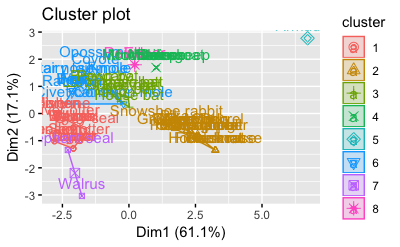

```r
print(k)
```

```
K-means clustering with 8 clusters of sizes 17, 19, 8, 7, 1, 10, 2, 2

Cluster means:
            I          i          C          c          P           p          M          m
1  1.00371702  0.3325619  0.8257228  0.9059288  0.6511006  0.50138831 -1.1970679 -0.9724500
2 -0.58511152 -1.1881600 -1.1927107 -1.0871146 -1.1094268 -1.25006099  0.4678196  0.3574411
3 -0.04446848  0.5353248  0.8257228  0.9059288 -0.3579589  0.05985675  0.4678196  0.3574411
4 -1.51192817  1.3970672 -1.1927107 -1.0871146  0.3610716  0.45491131  0.4678196  0.3574411
5 -1.51192817 -2.0499024 -1.1927107 -1.0871146 -2.1041756 -1.91541603  4.7561664  5.2722560
6  1.00371702  0.5353248  0.8257228  0.7066245  1.0184708  1.08699860  0.2105188  0.2591448
7 -0.25410558 -1.6190312  0.8257228  0.9059288  0.7719461  0.84996586 -1.6763537 -2.0999664
8 -1.51192817  1.3970672  0.8257228 -1.0871146  0.3610716  0.45491131  0.4678196  0.3574411

Clustering vector:
        Opossum Hairy tail mole     Common mole  Star nose mole       Brown bat Silver hair bat       Pigmy bat       House bat
              6               6               6               6               3               3               3               3
        Red bat       Hoary bat   Lump nose bat       Armadillo            Pika Snowshoe rabbit          Beaver          Marmot
              3               3               3               5               2               2               2               2
      Groundhog     Prairie Dog Ground Squirrel        Chipmunk   Gray squirrel    Fox squirrel   Pocket gopher    Kangaroo rat
              2               2               2               2               2               2               2               2
       Pack rat     Field mouse         Muskrat       Black rat     House mouse       Porcupine      Guinea pig          Coyote
              2               2               2               2               2               2               2               6
           Wolf             Fox            Bear       Civet cat         Raccoon          Marten          Fisher          Weasel
              6               6               6               6               6               1               1               1
           Mink          Ferrer       Wolverine          Badger           Skunk     River otter       Sea otter          Jaguar
              1               1               1               1               1               1               1               1
         Ocelot          Cougar            Lynx        Fur seal        Sea lion          Walrus       Grey seal   Elephant seal
              1               1               1               1               1               7               1               7
        Peccary             Elk            Deer           Moose        Reindeer        Antelope           Bison   Mountain goat
              3               8               4               4               8               4               4               4
        Musk ox  Mountain sheep
              4               4

Within cluster sum of squares by cluster:
[1] 1.491837e+01 1.556819e+01 4.244696e+00 7.549645e-31 0.000000e+00 1.858275e+01 2.223560e+00 0.000000e+00
 (between_SS / total_SS =  89.3 %)

Available components:

[1] "cluster"      "centers"      "totss"        "withinss"     "tot.withinss" "betweenss"    "size"         "iter"
[9] "ifault"
```

#### iii. We have 8 clusters of sizes 17, 19, 8, 7, 1, 10, 2 and 2

[output not shown]

[output cut: 7 more lines]

```r
cluster1Indices <- which(k$cluster == 1)
cluster2Indices <- which(k$cluster == 2)
cluster3Indices <- which(k$cluster == 3)
cluster4Indices <- which(k$cluster == 4)
cluster5Indices <- which(k$cluster == 5)
cluster6Indices <- which(k$cluster == 6)
cluster7Indices <- which(k$cluster == 7)
cluster8Indices <- which(k$cluster == 8)
cluster1 <- mammals[cluster1Indices, 0]
cluster2 <- mammals[cluster2Indices, 0]
cluster3 <- mammals[cluster3Indices, 0]
cluster4 <- mammals[cluster4Indices, 0]
cluster5 <- mammals[cluster5Indices, 0]
cluster6 <- mammals[cluster6Indices, 0]
cluster7 <- mammals[cluster7Indices, 0]
cluster8 <- mammals[cluster8Indices, 0]
cluster1

cluster2
```

[output not shown]

| Pika |
| --- |
| Snowshoe rabbit |
| Beaver |
| Marmot |
| Groundhog |
| Prairie Dog |
| Ground Squirrel |
| Chipmunk |
| Gray squirrel |
| Fox squirrel |

[output cut: 9 more lines]

```r
cluster3
```

| Brown bat |
| --- |
| Silver hair bat |
| Pigmy bat |
| House bat |
| Red bat |
| Hoary bat |
| Lump nose bat |
| Peccary |

```r
cluster4
```

| Deer |
| --- |
| Moose |
| Antelope |
| Bison |
| Mountain goat |
| Musk ox |
| Mountain sheep |

```r
cluster5
```

| Armadillo |
| --- |

```r
cluster6
```

| Opossum |
| --- |
| Hairy tail mole |
| Common mole |
| Star nose mole |
| Coyote |
| Wolf |
| Fox |
| Bear |
| Civet cat |
| Raccoon |

```r
cluster7
```

| Walrus |
| --- |
| Elephant seal |

```r
cluster8
```

| Elk |
| --- |
| Reindeer |

#### iv. and v. These are the total SSE an the SSE of each cluster:

```r
k$tot.withinss
```

```
[1] 55.53757
```

```r
k$withinss[1]
```

```
[1] 14.91837
```

```r
k$withinss[2]
```

```
[1] 15.56819
```

```r
k$withinss[3]
```

```
[1] 4.244696
```

```r
k$withinss[4]
```

```
[1] 7.549645e-31
```

```r
k$withinss[5]
```

```
[1] 0
```

```r
k$withinss[6]
```

```
[1] 18.58275
```

```r
k$withinss[7]
```

```
[1] 2.22356
```

```r
k$withinss[8]
```

```
[1] 0
```

## 2.2 Hierarchical clustering

### a)

```r
set.seed(1122)
mammals.sampled <- sample_n(mammals, 35)
single <- eclust(mammals.sampled, FUNcluster = "hclust", hc_method = "single")
```

```
Clustering k = 1,2,..., K.max (= 10): .. done
Bootstrapping, b = 1,2,..., B (= 100)  [one "." per sample]:
.................................................. 50
.................................................. 100
```

```r
complete <- eclust(mammals.sampled, FUNcluster = "hclust", hc_method = "complete")
```

```
Clustering k = 1,2,..., K.max (= 10): .. done
Bootstrapping, b = 1,2,..., B (= 100)  [one "." per sample]:
.................................................. 50
.................................................. 100
```

```r
average <- eclust(mammals.sampled, FUNcluster = "hclust", hc_method = "average")
```

```
Clustering k = 1,2,..., K.max (= 10): .. done
Bootstrapping, b = 1,2,..., B (= 100)  [one "." per sample]:
.................................................. 50
.................................................. 100
```

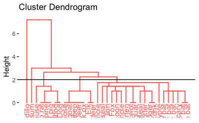

```r
fviz_dend(single) + geom_hline(yintercept = 2)
```

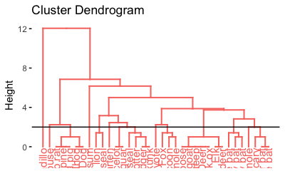

```r
fviz_dend(complete) + geom_hline(yintercept = 2)
```

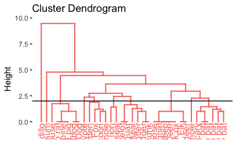

```r
fviz_dend(average) + geom_hline(yintercept = 2)
```

```r
single.cut<-cutree(single, h=2)
table(single.cut)
```

```
single.cut
 1  2  3  4  5
20  1  6  7  1
```

```r
complete.cut<-cutree(complete, h=2)
table(complete.cut)
```

```
complete.cut
 1  2  3  4  5  6  7  8  9 10 11 12
 4  1  6  3  5  1  7  1  3  1  2  1
```

```r
average.cut<-cutree(average, h=2)
table(average.cut)
```

```
average.cut
 1  2  3  4  5  6  7  8  9 10
 6  1  6  6  7  1  4  1  2  1
```

### b)

#### The two-singleton clusters are:

#### - Single method (5): {Groundhog, Prairie dog}, {Elk, Reindeer}, {Ocelot, Jaguar}, {Badger, Skunk}, {Silver Hair Bat, Lump nose bat}.

#### - Complete method (8): {Groundhog, Prairie dog}, {Sea lion, Elephant seal}, {Ocelot, Jaguar}, {Badger, Skunk}, {Racoon, Star nose mole}, {Elk, Reindeer}, {Hoary bat, Pigmy bat}, {Silver Hair Bat, Lump nose bat}.

#### - Average method (8): {Groundhog, Prairie dog}, {Racoon, Star nose mole}, {Sea lion, Elephant seal}, {Ocelot, Jaguar}, {Badger, Skunk}, {Elk, Reindeer}, {Silver Hair Bat, Lump nose bat}, {Hoary bat, Pigmy bat}.

### c)

#### Single method is purer than complete and average methods according to the purity definition, since it produces 5 two-singleton clusters and the others 8 each.

### d)

#### Drawing a horizontal line at a height of 2 we obtain 5 clusters for the simple method, 12 clusters for the complete method and 10 clusters for the average method.

### e)

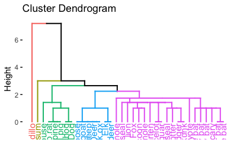

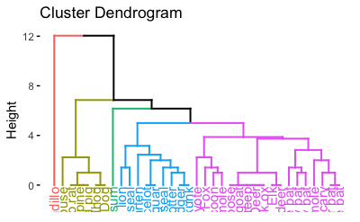

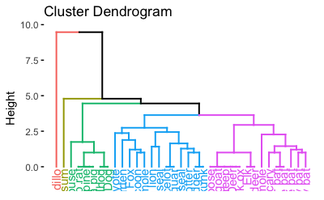

```r
single2 <- eclust(mammals.sampled, FUNcluster = "hclust", k = 5, hc_method = "single")
complete2 <- eclust(mammals.sampled, FUNcluster = "hclust", k = 5, hc_method = "complete")
average2 <- eclust(mammals.sampled, FUNcluster = "hclust", k = 5, hc_method = "average")
fviz_dend(single2)
fviz_dend(complete2)

fviz_dend(average2)
```

### f)

```r
single.stats <- cluster.stats(dist(mammals.sampled), single2$cluster)
single.stats$dunn
```

```
[1] 0.4472136
```

```r
single.stats$avg.silwidth
```

```
[1] 0.4446204
```

```r
complete.stats <- cluster.stats(dist(mammals.sampled), complete2$cluster)
complete.stats$dunn
```

```
[1] 0.3651484
```

```r
complete.stats$avg.silwidth
```

```
[1] 0.3985958
```

```r
average.stats <- cluster.stats(dist(mammals.sampled), average2$cluster)
average.stats$dunn
```

```
[1] 0.420084
```

```r
average.stats$avg.silwidth
```

```
[1] 0.4133625
```

### g)

#### The best method according to the Dunn and the Silhouette widths is the single method since it has greater values for both indicators than the complete and average method.

## 2.3 K-Means and PCA

### a)

```r
htru2 <- read.csv("HTRU_2-small.csv", sep = ",", header = TRUE)
htru2.scaled <- as.data.frame(scale(htru2[, 1:8]))
pca <- prcomp(htru2.scaled)
names(pca)
```

```
[1] "sdev"     "rotation" "center"   "scale"    "x"
```

```r
pca$sdev
```

```
[1] 2.0390930 1.4580613 0.8975401 0.6742584 0.5111361 0.3984421 0.1434342 0.1239556
```

```r
pca$rotation <- -pca$rotation
pca$rotation
```

```
                       PC1        PC2         PC3         PC4          PC5         PC6          PC7          PC8
mean            -0.3621185  0.3557532  0.01903077  0.28110182 -0.751127908  0.02210498  0.313434107 -0.002602825
std.dev         -0.2113048  0.4360516 -0.42887573 -0.75850013 -0.011659622  0.04150390 -0.063675726 -0.006273999
kurtosis         0.4152927 -0.3181695 -0.09423843 -0.30579508 -0.142778760  0.04444483  0.775594182 -0.001057761
skewness         0.3982761 -0.3111845 -0.08440847 -0.18828876 -0.638696703 -0.02799052 -0.541395908 -0.011682875
mean.dm.snr      0.3410716  0.2537362 -0.57746591  0.34179528  0.065190989 -0.59623381  0.032101651 -0.090675620
std.dev.dm.snr   0.3883051  0.3139829 -0.22917201  0.24818696  0.053784780  0.75929114 -0.043036463 -0.235051714
kurtosis.dm.snr -0.3720056 -0.4072348 -0.27735030  0.03326659 -0.000972254  0.02144172  0.009069735 -0.785620005
skewness.dm.snr -0.2960231 -0.3955042 -0.58033429  0.19279159  0.014424030  0.25010489 -0.009147940  0.564930160
```

```r
pca$x <- -pca$x
head(pca$x)
```

```
            PC1        PC2        PC3        PC4          PC5        PC6         PC7         PC8
[1,]  6.4382447 -0.0143551 -1.7949659  0.5409399  0.640870430 -0.8842372  0.53879181 -0.06119893
[2,] -0.1832529  0.4100026  0.7869431  0.1811806 -0.153274472 -0.1057186  0.10645938  0.04274356
[3,]  2.8551976  3.1442976 -1.3144753  1.3325658  0.452856354  0.2608973 -0.05999555 -0.03346941
[4,] -1.4321637  0.2654070 -0.1436657 -0.2891339 -0.334167330 -0.1834382 -0.08579579  0.07053529
[5,]  0.2490399 -0.4812094  1.3479977  0.9813818  0.008091907 -0.3246550 -0.05746990  0.14355137
[6,] -1.5518398  0.4459989 -0.2396479 -0.3789096 -0.566835233 -0.1602054  0.14396044  0.08510066
```

```r
e <- eigen(cov(htru2.scaled))
var2firstComponents <- (e$values[1]+e$values[2])/(sum(e$values[1:8]))
var2firstComponents
```

```
[1] 0.7854804
```

#### i. Frist two components have a cumulative variance of 0.7854804

#### ii.

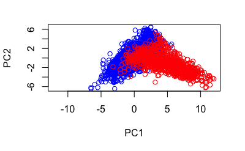

#### iii. We observe that class 0 samples are printed in blue in the negative part of the PC1 axis and class 1 samples in red in the positive part of the PC1 axis. Regarding the PC2 axis, both classes have positive and negative values.

### b)

#### i.

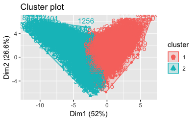

#### ii. The shape of the clusters is similar to the plot of the two principal components in a) ii. but rotated.

```r
print(k2)
```

```
K-means clustering with 2 clusters of sizes 8847, 1153

Cluster means:
        mean     std.dev   kurtosis  skewness mean.dm.snr std.dev.dm.snr kurtosis.dm.snr skewness.dm.snr
1  0.1910945  0.07626496 -0.2377641 -0.220951  -0.2870852     -0.2884001       0.2112272       0.1266174
2 -1.4662733 -0.58518308  1.8243700  1.695363   2.2028122      2.2129014      -1.6207523      -0.9715384

Clustering vector:
   [1] 2 1 2 1 1 1 1 1 1 1 1 1 1 2 1 1 1 1 1 1 1 1 2 1 1 1 1 1 2 1 1 1 1 2 1 1 1 1 1 1 1 1 1 1 1 1 1 1 1 1 1 1 1 1 1 1 1 1 1 1 1 1 2 1 1 1 2 1 1 1 2 2 2 1 2 2 1 1 1
  [80] 1 1 1 2 1 1 2 1 1 1 2 1 1 1 2 2 1 1 1 2 2 1 1 2 1 1 1 1 1 1 1 1 1 1 1 1 1 1 1 1 2 1 2 1 1 1 1 1 1 1 1 1 1 1 1 1 1 1 2 1 2 1 1 1 1 1 2 1 1 1 1 1 1 1 1 1 1 1 2
 [159] 2 1 1 1 2 1 1 1 1 2 2 1 1 1 1 1 1 1 1 1 1 1 1 1 1 1 1 1 1 1 1 1 1 1 1 1 1 1 1 1 1 1 1 1 2 1 2 1 1 1 1 1 1 2 1 1 1 1 1 2 1 1 1 1 1 1 1 1 1 1 1 1 1 1 1 1 1 1 1
 [238] 1 1 1 1 1 1 1 1 1 1 1 1 1 1 1 1 1 1 1 1 2 1 1 1 1 1 1 1 2 1 1 1 2 1 1 1 1 1 1 1 1 1 1 1 2 1 1 1 1 1 1 1 1 1 1 1 1 2 1 1 1 1 1 1 1 1 1 1 1 1 1 1 1 1 1 1 2 1 1
 [317] 1 1 1 1 1 1 2 2 1 1 1 1 1 1 1 1 2 1 2 1 1 1 1 1 2 1 1 1 1 1 1 1 1 2 1 1 2 1 1 1 1 1 1 1 2 1 1 1 1 1 1 1 1 1 1 1 1 1 1 1 1 1 1 1 1 2 1 2 1 1 2 1 2 1 1 1 1 1 1
 [396] 1 1 1 2 1 1 1 1 1 1 1 1 1 1 1 1 1 1 1 1 1 1 1 1 1 1 1 1 1 1 1 1 1 1 1 1 1 1 1 1 2 1 2 1 1 2 2 1 1 1 1 1 1 1 1 1 1 1 1 2 1 1 1 1 2 2 2 1 1 1 1 1 1 1 2 1 1 2 1
 [475] 2 1 1 1 1 1 1 1 1 1 1 1 2 1 1 1 1 1 1 1 1 1 1 1 1 1 1 2 1 1 1 1 1 1 1 2 2 1 1 1 1 1 1 1 1 1 2 1 1 1 1 1 1 1 1 1 1 1 1 1 1 1 2 1 1 1 1 1 1 1 1 1 1 1 1 1 2 2 1
 [554] 1 1 1 2 1 1 1 1 1 1 1 1 1 1 1 1 1 1 1 1 1 1 1 2 1 1 1 1 1 1 2 1 1 1 1 1 1 1 1 1 1 1 1 1 1 1 1 1 1 1 2 1 1 1 1 1 1 1 1 1 1 1 2 1 1 1 1 1 1 1 1 2 1 2 1 1 1 1 1
 [633] 1 1 1 1 1 1 1 1 1 1 1 1 2 1 1 2 1 1 1 1 2 1 1 1 1 1 2 1 1 1 1 1 1 1 1 1 1 1 1 1 1 1 1 1 1 1 1 1 2 1 1 1 1 1 1 1 1 1 1 2 1 1 1 2 1 2 2 2 1 1 1 1 1 1 1 1 1 1 1
 [712] 1 1 1 1 2 1 1 1 1 1 1 1 1 1 1 1 1 1 1 1 1 2 1 1 2 1 1 1 1 1 1 1 1 1 1 1 1 1 1 1 1 1 1 1 1 1 1 1 2 1 1 2 1 1 2 1 2 1 1 1 1 1 1 1 1 1 1 1 1 1 1 1 2 1 1 2 1 1 1
 [791] 1 1 2 1 1 1 1 1 1 1 2 1 1 1 1 1 1 1 1 1 1 1 1 1 2 1 2 1 1 1 1 1 1 1 1 1 1 1 2 1 1 1 1 1 1 1 1 1 1 2 1 1 1 2 1 1 1 1 1 2 2 1 1 1 1 1 1 2 1 1 2 1 1 1 1 2 1 1 1
 [870] 2 1 1 1 1 1 1 1 1 1 1 1 1 1 1 1 1 2 1 1 1 1 1 1 1 1 1 1 1 1 1 1 1 1 1 1 1 2 1 1 1 1 1 1 1 1 1 1 2 1 1 1 1 1 1 1 1 2 1 1 2 1 1 1 1 1 1 1 1 1 2 1 1 1 1 1 1 2 1
 [949] 1 1 1 1 1 1 1 1 1 2 1 1 1 2 1 2 1 1 2 1 1 1 1 1 2 2 1 1 1 1 1 2 1 1 1 1 1 1 1 1 2 1 1 1 1 1 2 1 1 1 1 1
 [ reached getOption("max.print") -- omitted 9000 entries ]

Within cluster sum of squares by cluster:
[1] 30015.49 21285.08
 (between_SS / total_SS =  35.9 %)

Available components:

[1] "cluster"      "centers"      "totss"        "withinss"     "tot.withinss" "betweenss"    "size"         "iter"         "ifault"
```

#### iii. We have two clusters of sizes 8847 and 1153.

```r
length(which(htru2$class == 0))
```

```
[1] 9041
```

```r
length(which(htru2$class == 1))
```

```
[1] 959
```

#### iv. The dataset has 9041 observation of class 0 and 959 observations of class 1.

#### v. Cluster 1 in the graph corresponds to the majority class and cluster 2 to the minority class.

```r
majorityIndices <- which(k2$cluster == 1)
majorityCluster <- htru2[majorityIndices, ]
length(which(majorityCluster$class == 0))
```

```
[1] 8624
```

```r
length(which(majorityCluster$class == 1))
```

```
[1] 223
```

#### vi. 8624 observations of cluster 1 belongs to the class 0 and 223 to the class 1.

#### vii. Cluster 1 represents class 0.

```r
variance <- k2$betweenss/k2$tot.withinss
variance
```

```
[1] 0.5592811
```

#### ix. The average Silhouette width of both the clusters is

```r
htru2.stats$avg.silwidth
```

```
[1] 0.6006794
```

#### x. The per cluster Silhouette width is

```r
htru2.stats$clus.avg.silwidths
```

```
        1         2
0.6592013 0.1516389
```

#### Cluster 1 is better than cluster 2 since its Silhouette width is higher.

### c)

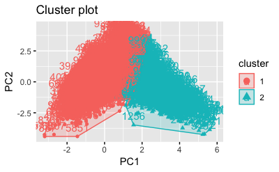

#### i. We can see how the shape of the two clusters is the same than in a(ii) and the same but rotated than in b(i).

#### ii. The average Silhoutte of both clusters is

```r
finalPCA.stats <- cluster.stats(dist(pca$x[, 1:2]), k3$cluster)
finalPCA.stats$avg.silwidth
```

```
[1] 0.6826261
```

#### iii. The per cluster Silhouette width is

```r
finalPCA.stats$clus.avg.silwidths
```

```
        1         2
0.7003259 0.4489076
```

#### Cluster 1 is better than cluster 2 since its Silhouette width is higher.

#### iv. All Silhouette widths are higher if we apply K-means on the result of the two principal component of the PCA instead of directly on the dataset, leading to the conclusion that performing PCA analysis provides a higher performance.